# Comparing Methods for Handling Imbalanced Datasets

Hamed Helisaz

### 1. Data Preparation 💾

This dataset is used for predicting the likelihood of a **cerebral stroke** based on various health and demographic factors. It is an **imbalanced classification problem**, making it suitable for evaluating models using metrics like **Precision**, **Recall**, **F1 Score**, **ROC-AUC**, and **PR-AUC**.

**Key Features Include:** - Age, Hypertension, Heart Disease - Average Glucose Level, BMI - Smoking Status, Gender, Work Type, Residence Type - Stroke (target variable)

**Class Imbalance:** The target variable (`stroke`) is highly imbalanced, with a small percentage of positive stroke cases.

**Source:** [Cerebral Stroke Prediction (Imbalanced Dataset) on Kaggle](https://www.kaggle.com/datasets/shashwatwork/cerebral-stroke-predictionimbalaced-dataset)

### 2. Exploratory Data Analysis 🔍

#### 2.1. Initial Data Overview 📊

**Format**

**Variables**

gender, age, hypertension, heart_disease, ever_married, work_type, Residence_type, avg_glucose_level, bmi, smoking_status, Class

```
## Rows: 41,938
## Columns: 11
## $ gender            <fct> Male, Male, Female, Female, Male, Female, Female, Fe…
## $ age               <dbl> 3, 58, 8, 70, 14, 47, 52, 75, 32, 74, 79, 79, 37, 37…
## $ hypertension      <fct> 0, 1, 0, 0, 0, 0, 0, 0, 0, 1, 0, 0, 0, 0, 0, 0, 0, 0…
## $ heart_disease     <fct> 0, 0, 0, 0, 0, 0, 0, 1, 0, 0, 0, 1, 0, 0, 0, 0, 0, 0…
## $ ever_married      <fct> No, Yes, No, Yes, No, Yes, Yes, Yes, Yes, Yes, Yes, …
## $ work_type         <fct> children, Private, Private, Private, Never_worked, P…
## $ Residence_type    <fct> Rural, Urban, Urban, Rural, Rural, Urban, Urban, Rur…
## $ avg_glucose_level <dbl> 95.12, 87.96, 110.89, 69.04, 161.28, 210.95, 77.59, …
## $ bmi               <dbl> 18.0, 39.2, 17.6, 35.9, 19.1, 50.1, 17.7, 27.0, 32.3…
## $ smoking_status    <int> 1, 3, 1, 2, 1, 1, 2, 3, 4, 3, 1, 2, 3, 2, 3, 3, 4, 3…
## $ Class             <fct> negative, negative, negative, negative, negative, ne…
```

#### 2.2. Visualization

###### 2.2.1. Distribution of Classes

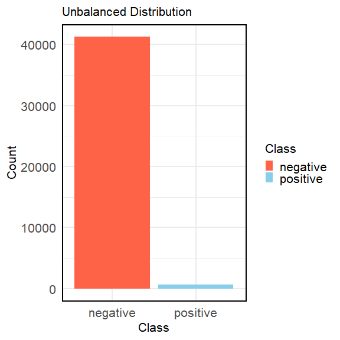

###### 2.2.2. Distribution of Predictors

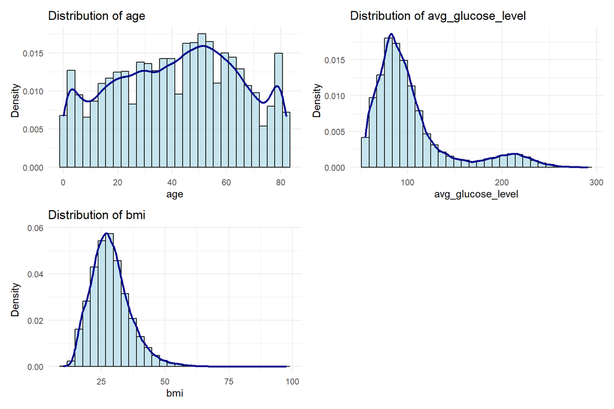

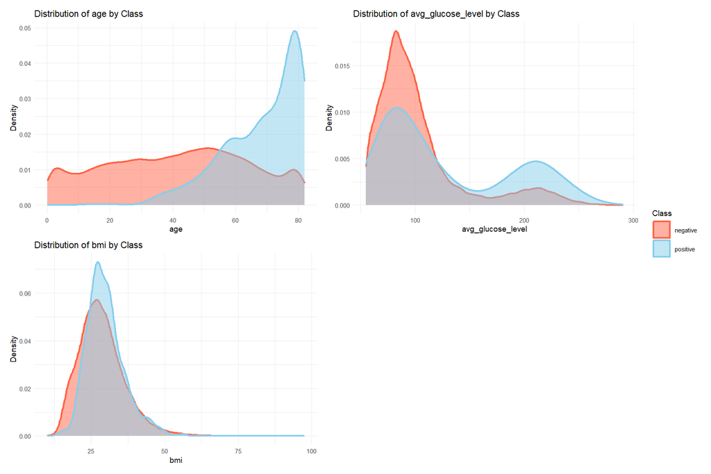

###### 2.2.3. Distribution of Predictors by Class - Contingency Tables

| gender | negative | positive |
| --- | --- | --- |
| Female | 24,588 (98.6%) | 357 (1.4%) |
| Male | 16,700 (98.3%) | 286 (1.7%) |
| Other | 7 (100%) | 0 (0.0%) |

| hypertension | negative | positive |
| --- | --- | --- |
| 0 | 37,797 (98.8%) | 471 (1.2%) |
| 1 | 3,498 (95.3%) | 172 (4.7%) |

| heart_disease | negative | positive |
| --- | --- | --- |
| 0 | 39,631 (98.8%) | 499 (1.2%) |
| 1 | 1,664 (92%) | 144 (8%) |

| ever_married | negative | positive |
| --- | --- | --- |
| No | 15,087 (99.6%) | 67 (0.4%) |
| Yes | 26,208 (97.8%) | 576 (2.2%) |

| work_type | negative | positive |
| --- | --- | --- |
| children | 6,059 (100%) | 1 (0%) |
| Govt_job | 5,167 (98.5%) | 77 (1.5%) |
| Never_worked | 176 (100%) | 0 (0.0%) |
| Private | 23,626 (98.5%) | 358 (1.5%) |
| Self-employed | 6,267 (96.8%) | 207 (3.2%) |

| Residence_type | negative | positive |
| --- | --- | --- |
| Rural | 20,619 (98.5%) | 315 (1.5%) |
| Urban | 20,676 (98.4%) | 328 (1.6%) |

| smoking_status | negative | positive |
| --- | --- | --- |
| 1 | 12,771 (99.3%) | 95 (0.7%) |
| 2 | 6,919 (97.5%) | 180 (2.5%) |
| 3 | 15,491 (98.4%) | 256 (1.6%) |
| 4 | 6,114 (98.2%) | 112 (1.8%) |

### 3. Methodology 🛠️

The following machine learning workflow is considered for all models:

**📦 Data Splitting:**  
The original dataset is divided into three parts: I used **stratified splits** to ensure the minority class is represented in all subsets.

- **Training set (≈56%)**: used to train the model.
- **Validation set (≈24%)**: used to tune hyperparameters and select the optimal classification threshold.
- **Test set (≈20%)**: held out and used **only once** for final model evaluation.

This 3-way split ensures that model selection and threshold tuning do not bias the final reported performance.

**⚖️ Handling Class Imbalance:**  
All training datasets are augmented using **oversampling techniques** such as **SMOTE**, **ADASYN**, or **SMOTE-ENN** to address the severe class imbalance (positive class ≈ 1%).  
However, both the **validation** and **test** sets are **not augmented** and retain their original class distributions to reflect real-world scenarios.

In addition to oversampling, we also apply **class weighting** during model training to further mitigate imbalance. The weighting scheme assigns higher penalties to misclassifications of the minority class. The weights are computed inversely proportional to class frequencies, using the formula:

$$\text{weight}_{\text{class}} = \frac{n_{\text{total}}}{2 \times
n_{\text{class}}}$$

where $n_{\text{class}}$ is the number of observations in a given class, and $n_{\text{total}}$ is the total number of training samples.

**🎯 Model Training & Threshold Selection:**  
All models are trained to **maximize the F1 score**, which balances precision and recall, making it particularly suitable for highly imbalanced classification tasks. The classification **threshold** is tuned on the **validation set**. This tuned threshold is then applied to the test set for **final evaluation**, which is performed only once.

**📊 Evaluation Metrics:**  
Model performance is assessed using the following metrics:

This methodology ensures fair comparison and realistic performance estimation.

#### 3.1. Generalized Linear Models (GLM) 🔢

In this section, we evaluate **logistic regression (GLM)** for handling the imbalanced dataset.  
We explore the following strategies:

1. **Baseline logistic regression** without any class imbalance treatment.
2. **Resampling approaches**: Random Over-Sampling (ROS), SMOTE, SMOTE-ENN, Random Under-Sampling (RUS)

The classification **threshold is tuned on the validation set** to maximize the **F1 score**,  
ensuring that the model achieves a balance between **precision** and **recall** while accounting for the class imbalance.

##### 3.1.1 Baseline GLM

ROC is used to find an optimal threshold for classification. This time, the threshold is 0.06

```
##           Reference
## Prediction negative positive
##   negative     7856       88
##   positive      403       40
##
## Sensitivity: 0.312
## Specificity: 0.951
## Precision:    0.09
## F1 Score:    0.14
```

##### 3.1.2 GLM + ROS

```
##
## negative positive
##    23126    23126
```

ROC is used to find an optimal threshold for classification. This time, the threshold is 0.87

```
##           Reference
## Prediction negative positive
##   negative     8047      102
##   positive      212       26
##
## Sensitivity: 0.203
## Specificity: 0.974
## Precision:    0.109
## F1 Score:    0.142
```

##### 3.1.3 GLM + SMOTE

ROC is used to find an optimal threshold for classification. This time, the threshold is 0.87

```
##           Reference
## Prediction negative positive
##   negative     7988       96
##   positive      271       32
##
## Sensitivity: 0.25
## Specificity: 0.967
## Precision:    0.106
## F1 Score:    0.148
```

##### 3.1.4 GLM + SMOTE-ENN

```
## Number of instances removed from majority class with ENN: 1544    Time needed: 2.34
```

```
##
## negative positive
##    21582    23126
```

ROC is used to find an optimal threshold for classification. This time, the threshold is 0.89

```
##           Reference
## Prediction negative positive
##   negative     7940       94
##   positive      319       34
##
## Sensitivity: 0.266
## Specificity: 0.961
## Precision:    0.096
## F1 Score:    0.141
```

##### 3.1.5 GLM + RUS

```
##
## negative positive
##      361      361
```

ROC is used to find an optimal threshold for classification. This time, the threshold is 0.85

```
##           Reference
## Prediction negative positive
##   negative     7895       92
##   positive      364       36
##
## Sensitivity: 0.281
## Specificity: 0.956
## Precision:    0.09
## F1 Score:    0.136
```

#### 3.2 Random Forest 🌲

Random Forest is a robust ensemble method that often performs well with unbalanced data due to its ability to handle non-linear relationships.  
In this section, we test different **Random Forest variations**:

The classification **threshold is tuned on the validation set** to maximize the **F1 score**,  
ensuring that the model achieves a balance between **precision** and **recall** while accounting for the class imbalance.

##### 3.2.1. Baseline RF

ROC is used to find an optimal threshold for classification. This time, the threshold is 0.04

```
##           Reference
## Prediction negative positive
##   negative     7530       62
##   positive      729       66
##
## Sensitivity: 0.516
## Specificity: 0.912
## Precision:    0.083
## F1 Score:    0.143
```

##### 3.2.2 RF + SMOTE

ROC is used to find an optimal threshold for classification. This time, the threshold is 0.1

```
##           Reference
## Prediction negative positive
##   negative     7718       94
##   positive      541       34
##
## Sensitivity: 0.266
## Specificity: 0.934
## Precision:    0.059
## F1 Score:    0.097
```

##### 3.2.3 RF + SMOTE-ENN

ROC is used to find an optimal threshold for classification. This time, the threshold is 0.07

```
##           Reference
## Prediction negative positive
##   negative     7310       72
##   positive      949       56
##
## Sensitivity: 0.438
## Specificity: 0.885
## Precision:    0.056
## F1 Score:    0.099
```

##### 3.2.4 RF + ADASYN

ROC is used to find an optimal threshold for classification. This time, the threshold is 0.05

```
##           Reference
## Prediction negative positive
##   negative     7399       70
##   positive      860       58
##
## Sensitivity: 0.453
## Specificity: 0.896
## Precision:    0.063
## F1 Score:    0.111
```

##### 3.2.5 Weighted RF

ROC is used to find an optimal threshold for classification. This time, the threshold is 0.05

```
##           Reference
## Prediction negative positive
##   negative     7627       67
##   positive      632       61
##
## Sensitivity: 0.477
## Specificity: 0.923
## Precision:    0.088
## F1 Score:    0.149
```

#### 3.3 Boosting (XGBoost) ⚡

In this section, we explore the **XGBoost** algorithm, a powerful gradient boosting technique, for handling the severe class imbalance.

As with previous models, the **classification threshold** is tuned on the **validation set** to maximize the **F1 score**, ensuring a balance between precision and recall.

##### 3.3.1 Baseline XGBoost

ROC is used to find an optimal threshold for classification. This time, the threshold is 0.06

```
##           Reference
## Prediction negative positive
##   negative     7840       94
##   positive      419       34
##
## Sensitivity: 0.266
## Specificity: 0.949
## Precision:    0.075
## F1 Score:    0.117
```

##### 3.3.2 XGBoost + SMOTE

Again, ROC is used to find an optimal threshold for classification. This time, the threshold is 0.03

```
##           Reference
## Prediction negative positive
##   negative     7365       70
##   positive      894       58
##
## Sensitivity: 0.453
## Specificity: 0.892
## Precision:    0.061
## F1 Score:    0.107
```

##### 3.3.3 XGBoost + SMOTE-ENN

Again, ROC is used to find an optimal threshold for classification. This time, the threshold is 0.04

```
##           Reference
## Prediction negative positive
##   negative     7296       63
##   positive      963       65
##
## Sensitivity: 0.508
## Specificity: 0.883
## Precision:    0.063
## F1 Score:    0.112
```

##### 3.3.4 XGBoost + ADASYN

Again, ROC is used to find an optimal threshold for classification. This time, the threshold is 0.02

```
##           Reference
## Prediction negative positive
##   negative     7074       58
##   positive     1185       70
##
## Sensitivity: 0.547
## Specificity: 0.857
## Precision:    0.056
## F1 Score:    0.101
```

##### 3.3.5 Weighted XGBoost

ROC is used to find an optimal threshold for classification. This time, the threshold is 0.61

```
##           Reference
## Prediction negative positive
##   negative     8089      114
##   positive      170       14
##
## Sensitivity: 0.109
## Specificity: 0.979
## Precision:    0.076
## F1 Score:    0.09
```

#### 3.4 Neural Networks (NN) 🧠

In this section, we explore **feed-forward Neural Networks (NN)** for the same task. Neural networks can capture complex patterns but are also sensitive to class imbalance.

As with previous models, the **classification threshold** is tuned on the **validation set** to maximize the **F1 score**, ensuring a balance between precision and recall.

##### 3.4.1 Baseline NN

```
## Epoch 10, Loss: 0.8758
## Epoch 20, Loss: 0.5139
## Epoch 30, Loss: 0.3425
## Epoch 40, Loss: 0.2486
## Epoch 50, Loss: 0.1878
## Epoch 60, Loss: 0.1481
## Epoch 70, Loss: 0.1244
## Epoch 80, Loss: 0.1150
## Epoch 90, Loss: 0.1133
## Epoch 100, Loss: 0.1131
```

ROC is used to find an optimal threshold for classification. This time, the threshold is 0

```
##           Reference
## Prediction negative positive
##   negative      368       15
##   positive     7891      113
##
## Sensitivity: 0.883
## Specificity: 0.045
## Precision:    0.014
## F1 Score:    0.028
```

##### 3.3.2 NN + SMOTE

```
## Epoch 10, Loss: 1.0368
## Epoch 20, Loss: 0.7554
## Epoch 30, Loss: 0.7048
## Epoch 40, Loss: 0.6794
## Epoch 50, Loss: 0.6611
## Epoch 60, Loss: 0.6434
## Epoch 70, Loss: 0.6324
## Epoch 80, Loss: 0.6200
## Epoch 90, Loss: 0.6084
## Epoch 100, Loss: 0.6008
```

ROC is used to find an optimal threshold for classification. This time, the threshold is 0.79

```
##           Reference
## Prediction negative positive
##   negative     8028      111
##   positive      231       17
##
## Sensitivity: 0.133
## Specificity: 0.972
## Precision:    0.069
## F1 Score:    0.09
```

##### 3.3.2 NN + SMOTE-ENN

```
## Epoch 10, Loss: 0.7083
## Epoch 20, Loss: 0.6928
## Epoch 30, Loss: 0.6817
## Epoch 40, Loss: 0.6718
## Epoch 50, Loss: 0.6617
## Epoch 60, Loss: 0.6553
## Epoch 70, Loss: 0.6477
## Epoch 80, Loss: 0.6409
## Epoch 90, Loss: 0.6311
## Epoch 100, Loss: 0.6192
```

ROC is used to find an optimal threshold for classification. This time, the threshold is 0.77

```
##           Reference
## Prediction negative positive
##   negative     7971      110
##   positive      288       18
##
## Sensitivity: 0.141
## Specificity: 0.965
## Precision:    0.059
## F1 Score:    0.083
```

##### 3.3.4 NN + ADASYN

```
## Epoch 10, Loss: 1.1005
## Epoch 20, Loss: 1.1087
## Epoch 30, Loss: 1.1078
## Epoch 40, Loss: 1.1078
## Epoch 50, Loss: 1.1061
## Epoch 60, Loss: 1.1097
## Epoch 70, Loss: 1.1114
## Epoch 80, Loss: 1.1084
## Epoch 90, Loss: 1.1065
## Epoch 100, Loss: 1.1023
```

Again, ROC is used to find an optimal threshold for classification. This time, the threshold is 0.88

```
##           Reference
## Prediction negative positive
##   negative     8003      118
##   positive      256       10
##
## Sensitivity: 0.078
## Specificity: 0.969
## Precision:    0.038
## F1 Score:    0.051
```

##### 3.3.5 Weighted NN

```
## Epoch 10, Loss: 1.6555
## Epoch 20, Loss: 1.6832
## Epoch 30, Loss: 1.6588
## Epoch 40, Loss: 1.6628
## Epoch 50, Loss: 1.6703
## Epoch 60, Loss: 1.6528
## Epoch 70, Loss: 1.6567
## Epoch 80, Loss: 1.6599
## Epoch 90, Loss: 1.6980
## Epoch 100, Loss: 1.6938
```

ROC is used to find an optimal threshold for classification. This time, the threshold is 1

```
##           Reference
## Prediction negative positive
##   negative     7827      114
##   positive      432       14
##
## Sensitivity: 0.109
## Specificity: 0.948
## Precision:    0.031
## F1 Score:    0.049
```

### 3.5 Model Comparison 📊

- **Baseline** (no adjustment)
- **Random Oversampling (ROS)**
- **SMOTE**
- **SMOTE-ENN**
- **Adaptive Synthetic (ADASYN)**
- **Class-Sensitive Weighting**

Model Performance Comparison

|  | Sensitivity | Specificity | Precision | F1_Score |
| --- | --- | --- | --- | --- |
| RF (Weighting) | 0.477 | 0.923 | 0.088 | 0.149 |
| GLM (SMOTE) | 0.25 | 0.967 | 0.106 | 0.148 |
| RF (Baseline) | 0.516 | 0.912 | 0.083 | 0.143 |
| GLM (SMOTE-ENN) | 0.266 | 0.961 | 0.096 | 0.141 |
| GLM (Baseline) | 0.312 | 0.951 | 0.09 | 0.14 |
| XGBoost (Baseline) | 0.266 | 0.949 | 0.075 | 0.117 |
| XGBoost (SMOTE-ENN) | 0.508 | 0.883 | 0.063 | 0.112 |
| RF (ADASYN) | 0.453 | 0.896 | 0.063 | 0.111 |
| XGBoost (SMOTE) | 0.453 | 0.892 | 0.061 | 0.107 |
| XGBoost (ADASYN) | 0.547 | 0.857 | 0.056 | 0.101 |
| RF (SMOTE-ENN) | 0.438 | 0.885 | 0.056 | 0.099 |
| RF (SMOTE) | 0.266 | 0.934 | 0.059 | 0.097 |
| NN (SMOTE) | 0.133 | 0.972 | 0.069 | 0.09 |
| XGBoost (Weighting) | 0.109 | 0.979 | 0.076 | 0.09 |
| NN (SMOTE-ENN) | 0.141 | 0.965 | 0.059 | 0.083 |
| NN (ADASYN) | 0.078 | 0.969 | 0.038 | 0.051 |
| NN (Weighting) | 0.109 | 0.948 | 0.031 | 0.049 |
| NN (Baseline) | 0.883 | 0.045 | 0.014 | 0.028 |

Note:  
Performance metrics for various classification models- those above 75% quantile are highlighted green

### 3.6 Improving the Best Model 🚀

Section 3.5 showed that the Random Forest model with class weighting achieved the best performance compared to other models. Building on that, I am experimenting with different weighting schemes to see if further improvements are possible.

So far, I have been using the following weighting scheme:

$$\text{weight}_{\text{class}} = \frac{n_{\text{total}}}{2 \times
n_{\text{class}}}$$

where:  
- $n_{\text{class}}$ is the number of samples in the given class  
- $n_{\text{total}}$ is the total number of samples in the training data

Now, I am testing alternative weighting strategies such as:

1. Adjusting the denominator to values other than 2
   $$\text{weight}_{\text{class}} = \frac{n_{\text{total}}}{r \times
   n_{\text{class}}}$$
2. Applying a direct inverse frequency weighting:
   $$\text{weight}_{\text{class}} = \frac{1}{n_{\text{class}}}$$
3. Applying Weighted Cross-Entropy (WCE)

$$\text{weight}_{\text{major}} = w \cdot \log(p_{major})
\text{weight}_{\text{minor}} = \log(1 - p_{major})$$

- $w$: Class weight applied to the positive class to increase its importance
- $p$: Model-predicted probability of the positive class
4. Applying Focal Loss
   $$\text{weight}_{\text{major}} = (1-p)^{\gamma} \log(p)
   \text{weight}_{\text{minor}} = p^{\gamma} \log(1-p)$$

Additionally, I am combining these weighting schemes with advanced resampling techniques such as **SMOTE** (Synthetic Minority Over-sampling Technique) and **SMOTE-ENN** (a hybrid of SMOTE and Edited Nearest Neighbors) to further balance the dataset and improve model generalization.

These combined approaches aim to increase the model’s ability to correctly classify the minority class without sacrificing overall accuracy.

##### 3.6.1 Adjusting Weighting Scale (r)

$$\text{weight}_{\text{class}} = \frac{n_{\text{total}}}{r \times
n_{\text{class}}}$$

```
##           Reference
## Prediction negative positive
##   negative     7597       75
##   positive      662       53
##
## Sensitivity: 0.414
## Specificity: 0.92
## Precision:    0.074
## F1 Score:    0.126
```

```
##           Reference
## Prediction negative positive
##   negative     7626       76
##   positive      633       52
##
## Sensitivity: 0.406
## Specificity: 0.923
## Precision:    0.076
## F1 Score:    0.128
```

```
##           Reference
## Prediction negative positive
##   negative     7556       69
##   positive      703       59
##
## Sensitivity: 0.461
## Specificity: 0.915
## Precision:    0.077
## F1 Score:    0.133
```

```
##           Reference
## Prediction negative positive
##   negative     7554       71
##   positive      705       57
##
## Sensitivity: 0.445
## Specificity: 0.915
## Precision:    0.075
## F1 Score:    0.128
```

```
##           Reference
## Prediction negative positive
##   negative     7453       62
##   positive      806       66
##
## Sensitivity: 0.516
## Specificity: 0.902
## Precision:    0.076
## F1 Score:    0.132
```

##### 3.6.2 Direct Inverse Frequency Weighting

$$\text{weight}_{\text{class}} = \frac{1}{n_{\text{class}}}$$

```
##           Reference
## Prediction negative positive
##   negative     7669       80
##   positive      590       48
##
## Sensitivity: 0.375
## Specificity: 0.929
## Precision:    0.075
## F1 Score:    0.125
```

##### 3.6.3 Weighted Cross-Entropy (WCE) with Different Ratios

$$\text{weight}_{\text{major}} = - w \cdot \log(p_{major}) \\
\text{weight}_{\text{minor}} = - \log(1 - p_{major})$$

```
##           Reference
## Prediction negative positive
##   negative     7601       74
##   positive      658       54
##
## Sensitivity: 0.422
## Specificity: 0.92
## Precision:    0.076
## F1 Score:    0.129
```

```
##           Reference
## Prediction negative positive
##   negative     7632       73
##   positive      627       55
##
## Sensitivity: 0.43
## Specificity: 0.924
## Precision:    0.081
## F1 Score:    0.136
```

```
##           Reference
## Prediction negative positive
##   negative     7648       75
##   positive      611       53
##
## Sensitivity: 0.414
## Specificity: 0.926
## Precision:    0.08
## F1 Score:    0.134
```

```
##           Reference
## Prediction negative positive
##   negative     7678       79
##   positive      581       49
##
## Sensitivity: 0.383
## Specificity: 0.93
## Precision:    0.078
## F1 Score:    0.129
```

```
##           Reference
## Prediction negative positive
##   negative     7859       95
##   positive      400       33
##
## Sensitivity: 0.258
## Specificity: 0.952
## Precision:    0.076
## F1 Score:    0.118
```

```
##           Reference
## Prediction negative positive
##   negative     7535       71
##   positive      724       57
##
## Sensitivity: 0.445
## Specificity: 0.912
## Precision:    0.073
## F1 Score:    0.125
```

##### 3.6.4 Focal Loss with Different Ratios

$$\text{weight}_{\text{major}} = (1-p)^{\gamma} \log(p) \\
\text{weight}_{\text{minor}} = p^{\gamma} \log(1-p)$$

```
##           Reference
## Prediction negative positive
##   negative     7458       69
##   positive      801       59
##
## Sensitivity: 0.461
## Specificity: 0.903
## Precision:    0.069
## F1 Score:    0.119
```

```
##           Reference
## Prediction negative positive
##   negative     7658       78
##   positive      601       50
##
## Sensitivity: 0.391
## Specificity: 0.927
## Precision:    0.077
## F1 Score:    0.128
```

```
##           Reference
## Prediction negative positive
##   negative     7755       82
##   positive      504       46
##
## Sensitivity: 0.359
## Specificity: 0.939
## Precision:    0.084
## F1 Score:    0.136
```

```
##           Reference
## Prediction negative positive
##   negative     7601       72
##   positive      658       56
##
## Sensitivity: 0.438
## Specificity: 0.92
## Precision:    0.078
## F1 Score:    0.133
```

```
##           Reference
## Prediction negative positive
##   negative     7431       59
##   positive      828       69
##
## Sensitivity: 0.539
## Specificity: 0.9
## Precision:    0.077
## F1 Score:    0.135
```

```
##           Reference
## Prediction negative positive
##   negative     7835       90
##   positive      424       38
##
## Sensitivity: 0.297
## Specificity: 0.949
## Precision:    0.082
## F1 Score:    0.129
```

##### 3.6.5 Comparing Weighting Schems

Performance Across Different Weighting Schema

| Weighting | Sensitivity | Specificity | Precision | F1_Score |
| --- | --- | --- | --- | --- |
| r = 0.5 | 0.4141 | 0.9198 | 0.0741 | 0.1257 |
| r = 1 | 0.4062 | 0.9234 | 0.0759 | 0.1279 |
| r = 1.5 | 0.4609 | 0.9149 | 0.0774 | 0.1326 |
| r = 2 | 0.4453 | 0.9146 | 0.0748 | 0.1281 |
| r = 3 | 0.5156 | 0.9024 | 0.0757 | 0.1320 |
| Inverse Frequency | 0.3750 | 0.9286 | 0.0752 | 0.1253 |
| WCE - Weights = 0.5 | 0.4219 | 0.9203 | 0.0758 | 0.1286 |
| WCE - Weights = 1 | 0.4297 | 0.9241 | 0.0806 | 0.1358 |
| WCE - Weights = 1.5 | 0.4141 | 0.9260 | 0.0798 | 0.1338 |
| WCE - Weights = 2 | 0.3828 | 0.9297 | 0.0778 | 0.1293 |
| WCE - Weights = 3 | 0.2578 | 0.9516 | 0.0762 | 0.1176 |
| WCE - Weights = 4 | 0.4453 | 0.9123 | 0.0730 | 0.1254 |
| FL - Gamma = 0.5 | 0.4609 | 0.9030 | 0.0686 | 0.1194 |
| FL - Gamma = 1 | 0.3906 | 0.9272 | 0.0768 | 0.1284 |
| FL - Gammma = 1.5 | 0.3594 | 0.9390 | 0.0836 | 0.1357 |
| FL - Gamma = 2 | 0.4375 | 0.9203 | 0.0784 | 0.1330 |
| FL - Gamma = 3 | 0.5391 | 0.8997 | 0.0769 | 0.1346 |
| FL - Gamma = 4 | 0.2969 | 0.9487 | 0.0823 | 0.1288 |

##### 3.6.6 RF + WCE + SMOTE

Building on this, the next step is to combine WCE with sampling techniques to further enhance performance. Specifically, we will integrate WCE with:

SMOTE (Synthetic Minority Oversampling Technique): which generates synthetic samples for the minority class to balance the dataset.

SMOTE-ENN (SMOTE + Edited Nearest Neighbors): which combines oversampling with data cleaning by removing ambiguous and noisy samples using nearest neighbors.

This hybrid approach aims to leverage both algorithm-level (WCE) and data-level (SMOTE/SMOTE-ENN) methods to improve predictive accuracy—especially for the minority class.

We will implement and evaluate the following combinations:

Weighted Cross-Entropy (weight = 1) + SMOTE

Weighted Cross-Entropy (weight = 1) + SMOTE-ENN

```
##           Reference
## Prediction negative positive
##   negative     7419       84
##   positive      840       44
##
## Sensitivity: 0.344
## Specificity: 0.898
## Precision:    0.05
## F1 Score:    0.087
```

```
##           Reference
## Prediction negative positive
##   negative     7954      108
##   positive      305       20
##
## Sensitivity: 0.156
## Specificity: 0.963
## Precision:    0.062
## F1 Score:    0.088
```

### 3.7 Quantification

Since the evaluation score was low, I am now using quantification methods using two approaches for our best model so far, weighted random forest with different weights, and our baseline model.

*Probabilistic Classify & Count (PCC): adding the predicted probabilities.

*Adjusted Classify & Count (ACC): Using classifier’s known error rates (calculated from a training set) to correct the raw prediction counts from a test set.

#### 3.7.1 PCC (Weighted RF)

| Weight ratio r | PCC summary across bootstraps - Adjusting R Median PCC | PCC summary across bootstraps - Adjusting R 95% CI (bootstrap) |
| --- | --- | --- |
| 0.5 | 126 | [125, 127] |
| 1.0 | 126 | [125, 128] |
| 1.5 | 126 | [125, 128] |
| 2.0 | 126 | [124, 128] |
| 3.0 | 126 | [125, 128] |

| Weight ratio w | PCC summary across bootstraps - WCE Adjusting W Median PCC | PCC summary across bootstraps - WCE Adjusting W 95% CI (bootstrap) |
| --- | --- | --- |
| 0.5 | 126 | [124, 127] |
| 1.0 | 126 | [125, 128] |
| 1.5 | 126 | [125, 128] |
| 2.0 | 126 | [125, 127] |
| 3.0 | 126 | [124, 128] |
| 4.0 | 126 | [124, 128] |

Actual Prevalence in Test Set is 128.

#### 3.7.2 ACC (Weighted RF)

[output not shown]

| Weight ratio r | ACC summary across bootstraps - Adjusting R Median ACC | ACC summary across bootstraps - Adjusting R 95% CI (bootstrap) |
| --- | --- | --- |
| 0.5 | 193.5 | [139, 244] |
| 1.0 | 191.0 | [139, 240] |
| 1.5 | 194.0 | [140, 236] |
| 2.0 | 190.0 | [139, 236] |
| 3.0 | 192.0 | [139, 241] |

| Weight ratio w | ACC summary across bootstraps - WCE Adjusting W Median ACC | ACC summary across bootstraps - WCE Adjusting W 95% CI (bootstrap) |
| --- | --- | --- |
| 0.5 | 184.5 | [137, 238] |
| 1.0 | 192.0 | [138, 248] |
| 1.5 | 195.0 | [137, 241] |
| 2.0 | 191.5 | [139, 247] |
| 3.0 | 193.0 | [140, 233] |
| 4.0 | 188.0 | [139, 244] |

Actual Prevalence in Test Set is 128.

#### 3.7.3 PCC (Baseline GLM)

Actual Prevalence in Test Set for is 128 and the predicted PCC from GLM Baseline is 124.

#### 3.7.4 ACC (Baseline GLM)

Actual Prevalence in Test Set for is 128 and the predicted ACC from GLM Baseline is 408.